# Practical ML - Lesson Project

Christian Willig

22 January 2017

```r
knitr::opts_chunk$set(echo = FALSE)
```

## Setting the scene

Using devices such as Jawbone Up, Nike FuelBand, and Fitbit it is now possible to collect a large amount of data about personal activity relatively inexpensively. These type of devices are part of the quantified self movement  a group of enthusiasts who take measurements about themselves regularly to improve their health, to find patterns in their behavior, or because they are tech geeks. One thing that people regularly do is quantify how much of a particular activity they do, but they rarely quantify how well they do it. In this project, your goal will be to use data from accelerometers on the belt, forearm, arm, and dumbell of 6 participants. They were asked to perform barbell lifts correctly and incorrectly in 5 different ways. More information is available from the website here: http://groupware.les.inf.puc-rio.br/har (see the section on the Weight Lifting Exercise Dataset)."

## Data

The data for this project come from this source: http://groupware.les.inf.puc-rio.br/har. The information has been generously provided for use use in this cousera course by the authors, Velloso, E.; Bulling, A.; Gellersen, H.; Ugulino, W.; Fuks, H. They have allowed the use of their paper “Qualitative Activity Recognition of Weight Lifting Exercises. Proceedings of 4th International Conference in Cooperation with SIGCHI (Augmented Human ’13) . Stuttgart, Germany: ACM SIGCHI, 2013.

The training data for this project are available here:

https://d396qusza40orc.cloudfront.net/predmachlearn/pml-training.csv

The test data are available here:

https://d396qusza40orc.cloudfront.net/predmachlearn/pml-testing.csv

## Loading data

Loading Libraries

```r
library("ggplot2")
library("caret")

library("randomForest")
library("e1071")
library("gbm")
library("doParallel")
library("survival")
library("splines")
library("plyr")
library("RCurl")

# Setting the seed
set.seed(321)
```

Loading data from website

```r
#Loading training data from website provided.
trainingURL <- getURL('https://d396qusza40orc.cloudfront.net/predmachlearn/pml-training.csv', ssl.verifyhost=FALSE, ssl.verifypeer=FALSE)

train <- read.csv(textConnection(trainingURL), header=T, na.strings = c("NA","#DIV/0!",""))

#Loading testing data from website provided.
testURL <- getURL('https://d396qusza40orc.cloudfront.net/predmachlearn/pml-testing.csv', ssl.verifyhost=FALSE, ssl.verifypeer=FALSE)

test <- read.csv(textConnection(testURL), header=T, na.strings = c("NA","#DIV/0!",""))

# Check dimensions for number of variables and number of observations
dim(train)
```

```
## [1] 19622   160
```

```r
dim(test)
```

```
## [1]  20 160
```

```r
# Delete columns with all missing values
train<-train[,colSums(is.na(train)) == 0]
test <-test[,colSums(is.na(test)) == 0]

# deleting non meaningful variables.
train  <-train[,-c(1:7)]
test <-test[,-c(1:7)]

# new datasets:
dim(train)
```

```
## [1] 19622    53
```

```r
dim(test)
```

```
## [1] 20 53
```

```r
#head(train)
#head(test)

# Partitioning data to allow cross validation.
ssample <- createDataPartition(y=train$classe, p=0.75, list=FALSE)
sTrain <- train[ssample, ]
sTest <- train[-ssample, ]
dim(sTrain)
```

```
## [1] 14718    53
```

```r
dim(sTest)
```

```
## [1] 4904   53
```

```r
#head(sTrain)
#head(sTest)
```

## Previewing data

Charting the output variable will show the frequency of each level in the sTrain data set and compare one another. The variable “classe” contains 5 levels: A, B, C, D and E.

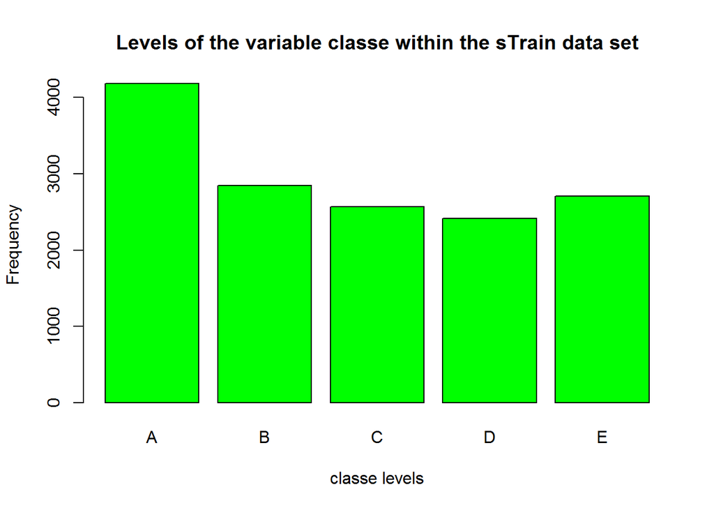

From the charrt, it is reasonable to say that each level frequency is within the same order of magnitud between each other. Level A is the one with the highest frequency with more than 4000 occurrences while level D is the least frequent with about 2500 occurrences.

## First prediction model

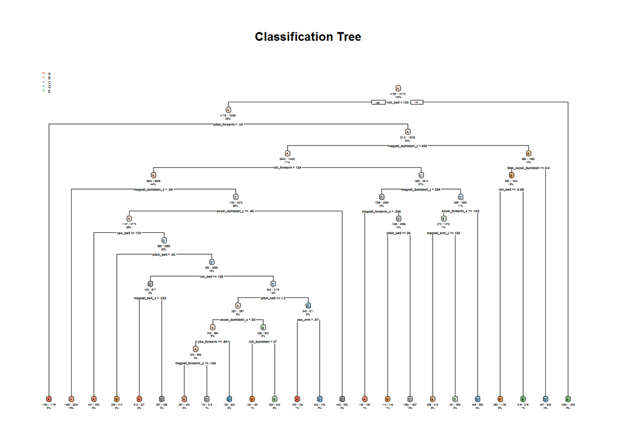

```r
library(rpart) # Regressive Partitioning and Regression trees
library(rpart.plot) # Decision Tree plot

model_one <- rpart(classe ~ ., data=sTrain, method="class")

# Executing the prediction on the test data
prediction_one <- predict(model_one, sTest, type = "class")

# Let's plot the decision tree
rpart.plot(model_one, main="Classification Tree", extra=102, under=TRUE, faclen=0)
```

```r
# Testing results on sTest data set:
print(confusionMatrix(prediction_one, sTest$classe))
```

```
## Confusion Matrix and Statistics
##
##           Reference
## Prediction    A    B    C    D    E
##          A 1284  196   21   85   35
##          B   34  558  102   44   76
##          C   40   88  657  121   99
##          D   13   69   45  500   51
##          E   24   38   30   54  640
##
## Overall Statistics
##
##                Accuracy : 0.742
##                  95% CI : (0.7296, 0.7542)
##     No Information Rate : 0.2845
##     P-Value [Acc > NIR] : < 2.2e-16
##
##                   Kappa : 0.6718
##  Mcnemar's Test P-Value : < 2.2e-16
##
## Statistics by Class:
##
##                      Class: A Class: B Class: C Class: D Class: E
## Sensitivity            0.9204   0.5880   0.7684   0.6219   0.7103
## Specificity            0.9040   0.9353   0.9141   0.9566   0.9635
## Pos Pred Value         0.7921   0.6855   0.6537   0.7375   0.8142
## Neg Pred Value         0.9662   0.9044   0.9492   0.9281   0.9366
## Prevalence             0.2845   0.1935   0.1743   0.1639   0.1837
## Detection Rate         0.2618   0.1138   0.1340   0.1020   0.1305
## Detection Prevalence   0.3305   0.1660   0.2049   0.1383   0.1603
## Balanced Accuracy      0.9122   0.7616   0.8412   0.7892   0.8369
```

## Second prediction model

```r
model_two <- randomForest(classe ~. , data=sTrain, method="class")

# Predicting:
prediction_two <- predict(model_two, sTest, type = "class")

# Test results on subTesting data set:
print(confusionMatrix(prediction_two, sTest$classe))
```

```
## Confusion Matrix and Statistics
##
##           Reference
## Prediction    A    B    C    D    E
##          A 1395    4    0    0    0
##          B    0  945    3    0    0
##          C    0    0  852   10    1
##          D    0    0    0  794    1
##          E    0    0    0    0  899
##
## Overall Statistics
##
##                Accuracy : 0.9961
##                  95% CI : (0.994, 0.9977)
##     No Information Rate : 0.2845
##     P-Value [Acc > NIR] : < 2.2e-16
##
##                   Kappa : 0.9951
##  Mcnemar's Test P-Value : NA
##
## Statistics by Class:
##
##                      Class: A Class: B Class: C Class: D Class: E
## Sensitivity            1.0000   0.9958   0.9965   0.9876   0.9978
## Specificity            0.9989   0.9992   0.9973   0.9998   1.0000
## Pos Pred Value         0.9971   0.9968   0.9873   0.9987   1.0000
## Neg Pred Value         1.0000   0.9990   0.9993   0.9976   0.9995
## Prevalence             0.2845   0.1935   0.1743   0.1639   0.1837
## Detection Rate         0.2845   0.1927   0.1737   0.1619   0.1833
## Detection Prevalence   0.2853   0.1933   0.1760   0.1621   0.1833
## Balanced Accuracy      0.9994   0.9975   0.9969   0.9937   0.9989
```

## Conclusion

As we can see in the results, the Random Forest algorithm performed better than Decision Trees.

## Submission

```r
# prediction of output levels from the original Testing data set using Random Forest algorithm
predict_test <- predict(model_two, test, type="class")
predict_test
```

```
##  1  2  3  4  5  6  7  8  9 10 11 12 13 14 15 16 17 18 19 20
##  B  A  B  A  A  E  D  B  A  A  B  C  B  A  E  E  A  B  B  B
## Levels: A B C D E
```

```r
# Writing files as requested in submission
pml_write_files = function(x){
  n = length(x)
  for(i in 1:n){
    filename = paste0("problem_id_",i,".txt")
    write.table(x[i],file=filename,quote=FALSE,row.names=FALSE,col.names=FALSE)
  }
}

pml_write_files(predict_test)
```